# Week 4: review – Hands-on

### Random Forest

```r
message()
```

```r
message('Elapsed time: ', rf_time['elapsed'] %>% round(3), ' seconds')
```

```
Elapsed time: 2006.16 seconds
```

```r
message('Used memory: ',
        format(rf_mem/(2^20), digits = 3, scientific = FALSE),
        ' MB')
```

```
Used memory: 3.47 MB
```

```r
rf_rmse <- (predict(rf_model, test_tree[-1]) - test_tree[[1]])^2 %>%
    mean %>%
    sqrt
message('Test rmse: ', rf_rmse)
```

```
Test rmse: 15.581046169042
```

```r
final_rf_param <- rf_model$bestTune
message('Final tuned parameter is: ',
        names(final_rf_param)[[1]], ' = ',
        final_rf_param[[1]] %>% round(3)
)
```

```
Final tuned parameter is: mtry = 4
```

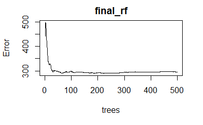

```r
final_rf <- rf_model$finalModel
plot(final_rf)
```

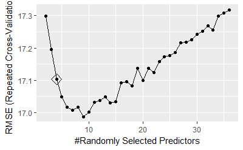

```r
ggplot(rf_model, highlight = TRUE)
```

As we can see, the standard approach for random forest adopted by `caret` to consider the maximum number of tree fixed at 500 is acceptable for this example, i.e. that number is sufficient to permit to the error rate to go flat. On the other hand, we can appreciate that `mtry` selected is 4 (with the best one being 9), and this is a demonstration that the best performance for the random forest algrorithm is achived when it resamples few variables each time. Furthermore, we can see that the error grows very quickly as the `mtry` decreases down to very low level.

### Random Forest + Boruta

```r
message()
```

```r
message('Elapsed time: ', boruta_time['elapsed'] %>% round(3), ' seconds')
```

```
Elapsed time: 6194.62 seconds
```

```r
message('Used memory: ',
        format(boruta_mem/(2^20), digits = 3, scientific = FALSE),
        ' MB')
```

```
Used memory: 3.44 MB
```

```r
boruta_rmse <- (predict(boruta_model, test_tree[-1]) - test_tree[[1]])^2 %>%
    mean %>%
    sqrt
message('Test rmse: ', boruta_rmse)
```

```
Test rmse: 16.1396582910279
```

```r
final_boruta_param <- boruta_model$bestTune
message('Final tuned parameter is: ',
        names(final_boruta_param)[[1]], ' = ',
        final_boruta_param[[1]] %>% round(3)
)
```

```
Final tuned parameter is: mtry = 2
```

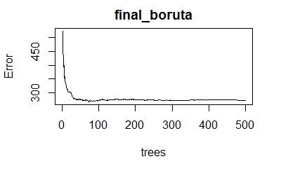

```r
final_boruta <- boruta_model$finalModel
plot(final_boruta)
```

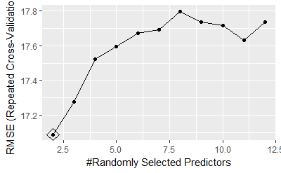

```r
ggplot(boruta_model, highlight = TRUE)
```

Random Forest combined with an automatic and blind Boruta, in presence of collinearity, hampers the performance of the algorithm leading to overfitting even in a cross validated environment. What is the possible reason for this?

## Boruta variable importance

```r
gc(verbose = FALSE, reset = TRUE)
```

```
          used  (Mb) gc trigger  (Mb) max used  (Mb)
Ncells 2323776 124.2    3886542 207.6  2323776 124.2
Vcells 4765318  36.4   10991486  83.9  4765318  36.4
```

```r
only_boruta_time <- system.time(
    only_boruta_mem <- pryr:::mem_change(
        boruta_varimp <- Boruta(
            x = train_tree[-1],
            y = train_tree[[1]]
        )
    )
)
message()
```

```r
message('Elapsed time: ', only_boruta_time['elapsed'] %>% round(3), ' seconds')
```

```
Elapsed time: 6.18 seconds
```

```r
message('Used memory: ',
        format(only_boruta_mem/(2^20), digits = 3, scientific = FALSE),
        ' MB')
```

```
Used memory: 0.0335 MB
```

```r
boruta_varimp
```

```
Boruta performed 99 iterations in 5.82518 secs.
 6 attributes confirmed important: bmi, collin_symptom_11, symptom_11, symptom_12, symptom_3 and 1 more;
 27 attributes confirmed unimportant: age, allergy_1, allergy_2, height, hemodynamic_1 and 22 more;
 3 tentative attributes left: collin_bmi, collin_symptom_11_12, symptom_6;
```

```r
final_decision <- data_frame(
    variable = names(boruta_varimp$finalDecision),
    decision = as.character(boruta_varimp$finalDecision)
) %>%
    group_by(decision) %>%
    summarise(
        variable = list(variable)
    )
final_decision$variable[[1]]
```

```
[1] "bmi"               "collin_symptom_11" "symptom_11"        "symptom_12"        "symptom_3"         "symptom_4"
```

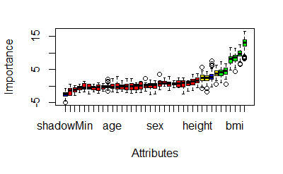

```r
plot(boruta_varimp)
```

The answer to the previuos question probably lies in the following: 1. Boruta is an algorithm that cannot detect automatically collinear variables. It just finds the important ones. As we can see, different collinear variables have been included in the important variables set. 2. Low number of variables selected.

So if random forest has to process models chosing from a small set of variables that suffer collinearity, it fails to deliver satisfying result.

# Comparisons

```r
times <- map_dbl(list(lasso2_time, ridge2_time, enet3_time, cart3_time,
                      ctree2_time, rf_time, boruta_time, only_boruta_time),
        ~ .['elapsed'] %>%
            round(3)
)
RAMs <- map_dbl(list(lasso2_mem, ridge2_mem, enet4_mem, cart3_mem,
                     ctree2_mem, rf_mem, boruta_mem, only_boruta_mem),
        ~ format(./(2^20),
                 digits = 3,
                 scientific = FALSE
        ) %>% as.double
)
rmse <- c(lasso2_rmse, ridge2_rmse, enet4_rmse, cart3_rmse, ctree2_rmse,
          rf_rmse, boruta_rmse, NA)
varselect <- map_chr(
    list(
        lasso2_best_beta %>% names %>% unique,
        ridge2_best_beta %>% names %>% unique,
        enet4_best_beta %>% names %>% unique,
        cart3_best_split$variable %>% unique,
        ctree2_best_split %>% unique
    ),
    ~ paste(., collapse = ' - ')
)
data_frame(
    MLT        = c('LASSO', 'ridge', 'enet', 'CART', 'ctree',
                   'RandomForest','RF_Boruta', 'Boruta_alone'
    ),
    `time (s)` = times,
    `RAM (MB)` = RAMs,
    RMSE       = rmse,
    `var used` = c(varselect,
                   rep('<NA>', length(rmse) - length(varselect))
    )
)
```

| MLT | time (s) | RAM (MB) | RMSE | var used |
| --- | --- | --- | --- | --- |
| LASSO | 18.31 | 0.3320 | 17.06380 | collin_symptom_11 - height - symptom_3_N |
| ridge | 700.56 | 0.3090 | 16.80719 | allergy_2_N - allergy_2_Y - bmi - collin_bmi - collin_symptom_11 - collin_symptom_11_12 - height - hemodynamic_2 - hemodynamic_3 - history_1_N - history_1_Y - history_2_N - history_2_Y - lifestyle_1_N… |
| enet | 1904.14 | 2.8500 | 17.01909 | collin_symptom_11 - height - symptom_3_N - symptom_3_Y |
| CART | 132.50 | 0.9110 | 14.98938 | collin_symptom_11 - symptom_12 |
| ctree | 468.75 | 1.0300 | 17.67203 | collin_symptom_11 - symptom_4 |
| RandomForest | 2006.16 | 3.4700 | 15.58105 |  |
| RF_Boruta | 6194.62 | 3.4400 | 16.13966 |  |
| Boruta_alone | 6.18 | 0.0335 | NA |  |

Again, keep in mind that we did not use an optimal dataset, but the one contaminated with several problems (collinearity, low number of obs and vars).

In terms of variables used, recurrent relevant variables are BMI, height, syntom4, syntom11, syntom 12 and their collinear counterparts.

# Links

- R help: `?`
- Breiman, L., Friedman, J., Stone, C. J., & Olshen, R. A. (1984). Classification and regression trees. CRC press.